# 6.3.Q1

## **Notebook 6.3: Efficient Deployment with Quantization**

## **Introduction**

🎉 Welcome to **Notebook 6.3**, where we take our **transformer model** to the **next level** with **Quantization!** 🔥 In the last notebook (**Notebook 6.2**), we explored how **KV Caching** speeds up transformer inference. But why stop there? We want our model to be **faster, lighter, and deployable anywhere!** 🚀

💡 **The Challenge?**  
Transformers are **powerful**, but they are also **computationally expensive** and **memory-hungry**. This makes deploying them on **resource-constrained devices**—like mobile phones, edge devices, or even embedded systems—a tough task.

💡 **The Solution?**  
Enter **Quantization!** 🎯 By **reducing the precision** of model weights and activations, quantization significantly lowers **memory footprint** and **computational requirements**, making inference **faster and more efficient**.

[figure not shown]

## **What’s Inside?**

🔍 We’ll break down **Quantization** step by step, making it easy to understand and apply to a **GPT-2 model**:

### **1️⃣ Understanding Quantization: Basics and Benefits**

✅ What is quantization, and why is it important? 🤔  
✅ How does it **reduce computational cost** while maintaining accuracy? 📊

### **3️⃣ Implementing an 8-bit Quantizer in a Transformer Model**

✅ Custom quantization techniques **applied to GPT-2**

### **4️⃣ Running GPT-2 with a Custom Quantizer**

✅ Benchmarking performance & accuracy 📊  
✅ Comparing quantized vs. non-quantized models 🤯

## **Why This Notebook Matters**

Quantization is a **game-changer** in deploying deep learning models **efficiently**. By the end of this notebook, you’ll:

✅ Understand **what quantization is** and why it’s crucial for deployment 🚀  
✅ Learn **how to implement quantization** in transformer models 🔧  
✅ Evaluate **performance trade-offs** and **accuracy impacts** 📊  
✅ Gain insights into **real-world applications** of quantized models 🌍

## **Looking Ahead**

Quantization is a **vast and evolving** field. This notebook lays the **foundation**, but we're just getting started! In upcoming notebooks, we'll explore **cutting-edge SOTA quantization techniques** to further **optimize transformers** for real-world deployment.

So, are you ready to **UNLOCK the full potential of Quantization** and **supercharge** your model? 🔥 Let’s dive in! 🚀

```python
import torch
import torch.nn as nn
import torch.nn.functional as F
```

## What Can We Quantize?

Quantization can be applied to:

1. **Weights**
2. **Activations**

### **Benefits of Quantization**

After applying quantization, we achieve:

- **Smaller models** 📉
- **Speed gains** 🚀
- **Faster operations** ⚡

### **Post-Training Quantization (PTQ)**

Quantization applied **after training** is known as **Post-Training Quantization (PTQ)**.

## **Linear Quantization: A Popular Method**

In **linear quantization**, we map **high-precision values** to **lower precision**, such as:

- `FP32 → INT8`

### **Formula**

The relationship between real values (`r`) and quantized values (`q`) is given by:

```
r = s * (q - z)
```

Where:

- `s` → Scale factor (from the original tensor)
- `z` → Zero point (from the quantized tensor)

To compute `q` from `r`, we rearrange the formula:

```
q = (r / s) + z
```

Since `q` must be an integer, we apply rounding:

```
q = int(round(r / s + z))
```

### **Python Implementation**

```python
def linear_Q(
        tensor,
        scale,
        zero,
        dtype = torch.int8
):

    scaled_shifted_tensor = tensor / scale + zero
    rounded = torch.round(scaled_shifted_tensor)

    q_min = torch.iinfo(dtype).min
    q_max = torch.iinfo(dtype).max

    q_tensor = rounded.clamp(q_min, q_max).to(dtype)

    return q_tensor
```

Lets test it

```python
### a dummy tensor to test the implementation
test_tensor=torch.tensor(
    [[191.6, -13.5, 728.6],
     [92.14, 295.5,  -184],
     [0,     684.6, 245.5]]
)
```

```python
scale = 3.5
zero = -70

quantized_tensor = linear_Q(test_tensor,scale,zero)

print(quantized_tensor)
```

```
tensor([[ -15,  -74,  127],
        [ -44,   14, -123],
        [ -70,  126,    0]], dtype=torch.int8)
```

Here we go back the other way (dequantization):

basically its just filpping the math formula

```python
dequantized_tensor = scale * (quantized_tensor.float() - zero)

print(dequantized_tensor)
```

```
tensor([[ 192.5000,  -14.0000,  689.5000],
        [  91.0000,  294.0000, -185.5000],
        [   0.0000,  686.0000,  245.0000]])
```

```python
## notice what we will get if not casting to float

dequantized_tensor = scale * (quantized_tensor - zero)

print(dequantized_tensor)
```

```
tensor([[ 192.5000,  -14.0000, -206.5000],
        [  91.0000,  294.0000, -185.5000],
        [   0.0000, -210.0000,  245.0000]])
```

```python
def linear_dequantization(quantized_tensor, scale, zero_point):
    return scale * (quantized_tensor.float() - zero_point)
```

## **Quantization Error Visualization Helper Functions**

In this section, we define several helper functions to assist with visualizing the effects of quantization on tensors. These functions allow us to:

1. Calculate the **quantization error** between the original and dequantized tensors.
2. **Plot heatmaps** of the original, quantized, dequantized tensors, and the quantization error tensor.

These tools help in understanding how quantization impacts the precision of the tensor values, providing insight into the trade-offs between model size reduction and potential loss of information during quantization.

```python
# ploting helper function for quantization error

import matplotlib.pyplot as plt
import seaborn as sns
from matplotlib.colors import ListedColormap

def quantization_error(tensor, dequantized_tensor):
    return (dequantized_tensor - tensor).abs().square().mean()

def plot_matrix(tensor, ax, title, vmin=0, vmax=1, cmap=None):
    """
    Plot a heatmap of tensors using seaborn
    """
    sns.heatmap(tensor.cpu().numpy(), ax=ax, vmin=vmin, vmax=vmax, cmap=cmap, annot=True, fmt=".2f", cbar=False)
    ax.set_title(title)
    ax.set_yticklabels([])
    ax.set_xticklabels([])


def plot_quantization_errors(original_tensor, quantized_tensor, dequantized_tensor, dtype = torch.int8, n_bits = 8):
    """
    A method that plots 4 matrices, the original tensor, the quantized tensor
    the de-quantized tensor and the error tensor.
    """
    # Get a figure of 4 plots
    fig, axes = plt.subplots(1, 4, figsize=(15, 4))

    # Plot the first matrix
    plot_matrix(original_tensor, axes[0], 'Original Tensor', cmap=ListedColormap(['white']))

    # Get the quantization range and plot the quantized tensor
    q_min, q_max = torch.iinfo(dtype).min, torch.iinfo(dtype).max
    plot_matrix(quantized_tensor, axes[1], f'{n_bits}-bit Linear Quantized Tensor', vmin=q_min, vmax=q_max, cmap='coolwarm')

    # Plot the de-quantized tensors
    plot_matrix(dequantized_tensor, axes[2], 'Dequantized Tensor', cmap='coolwarm')

    # Get the quantization errors
    q_error_tensor = abs(original_tensor - dequantized_tensor)
    plot_matrix(q_error_tensor, axes[3], 'Quantization Error Tensor', cmap=ListedColormap(['white']))

    fig.tight_layout()
    plt.show()
```

## **Scale and Zero Point Calculation for Quantization**

In linear quantization, we map the range of real numbers ([r_{\text{min}}, r_{\text{max}}]) to a fixed range of integers ([q_{\text{min}}, q_{\text{max}}]). The relationship is defined by the following formulas:

- For (r_{\text{min}}), (r_{\text{max}}):
  - `r_min = s(q_min - z)`
  - `r_max = s(q_max - z)`

Where:

- `s` is the **scale** factor, which ensures the range of real values fits into the quantized range.
- `z` is the **zero point**, which shifts the quantized values to align with the real value range.

We can derive the scale and zero point as follows:

- **Scale (s)**:  
  `s = (r_max - r_min) / (q_max - q_min)`
- **Zero Point (z)**:  
  `z = int(round(q_min - r_min / s))`

In case the calculated zero point `z` is out of the quantized range, we handle the edge cases by ensuring that `z` lies between `q_min` and `q_max`:

- If `z > q_max`, then set `z = q_max`.
- If `z < q_min`, then set `z = q_min`.

In the following code, we calculate the scale and zero point (`s`, `z`) based on a given real tensor, ensuring that we handle edge cases for `z` as well.

```python
def get_q_scale_and_zero_point(r_tensor, dtype=torch.int8):
    """
    Get quantization parameters (scale, zero point)
    for a floating point tensor
    """
    q_min, q_max = torch.iinfo(dtype).min, torch.iinfo(dtype).max
    r_min, r_max = r_tensor.min().item(), r_tensor.max().item()

    scale = (r_max-r_min)/(q_max-q_min)

    zero_point = q_min-(r_min/scale)

    # clip the zero_point to fall in [quantized_min, quantized_max]
    if zero_point < q_min or zero_point > q_max:
        zero_point = q_min
    else:
        # round and cast to int
        zero_point = int(round(zero_point))
    return scale, zero_point
```

```python
def linear_q_with_scale_and_zero_point(
    tensor, scale, zero_point, dtype = torch.int8):

    scaled_and_shifted_tensor = tensor / scale + zero_point

    rounded_tensor = torch.round(scaled_and_shifted_tensor)

    q_min = torch.iinfo(dtype).min
    q_max = torch.iinfo(dtype).max

    q_tensor = rounded_tensor.clamp(q_min,q_max).to(dtype)

    return q_tensor
```

```python
new_scale , new_zero = get_q_scale_and_zero_point(test_tensor, torch.int8)

print(new_scale)
print(new_zero)
```

```
3.578823433670343
-77
```

```python
quantized_tensor = linear_q_with_scale_and_zero_point(test_tensor, new_scale, new_zero)
dequantized_tensor = linear_dequantization (quantized_tensor, new_scale, new_zero)
```

```python
print(quantized_tensor)
print(dequantized_tensor)
```

```
tensor([[ -23,  -81,  127],
        [ -51,    6, -128],
        [ -77,  114,   -8]], dtype=torch.int8)
tensor([[ 193.2565,  -14.3153,  730.0800],
        [  93.0494,  297.0423, -182.5200],
        [   0.0000,  683.5552,  246.9388]])
```

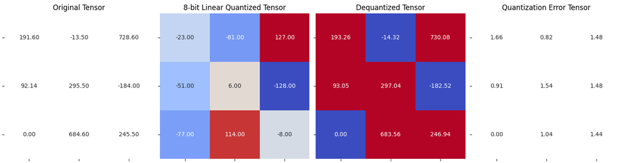

```python
plot_quantization_errors(test_tensor, quantized_tensor,
                         dequantized_tensor)
```

```python
dequantized_tensor - test_tensor
```

```
tensor([[ 1.6564, -0.8153,  1.4800],
        [ 0.9094,  1.5423,  1.4800],
        [ 0.0000, -1.0447,  1.4388]])
```

```python
(dequantized_tensor - test_tensor).square()
```

```
tensor([[2.7438, 0.6647, 2.1903],
        [0.8270, 2.3788, 2.1904],
        [0.0000, 1.0915, 2.0702]])
```

```python
(dequantized_tensor - test_tensor).square().mean()
```

```
tensor(1.5730)
```

or just use the helper function

```python
error = quantization_error(test_tensor, dequantized_tensor)
error
```

```
tensor(1.5730)
```

Lets put it together

```python
def linear_quantization(r_tensor, n_bits, dtype=torch.int8):
    """
    linear quantization
    """

    scale, zero_point = get_q_scale_and_zero_point(r_tensor)

    quantized_tensor = linear_q_with_scale_and_zero_point(
        r_tensor, scale=scale, zero_point=zero_point, dtype=dtype)

    return quantized_tensor, scale, zero_point
```

```python
r_tensor = torch.randn((4,4))
r_tensor
```

```
tensor([[ 0.2636, -0.7202,  0.3398,  0.7838],
        [-1.0119, -0.3556,  0.2909, -0.0386],
        [ 1.6359,  0.9961, -0.2396, -1.2248],
        [ 0.4516, -0.6139, -1.1917, -1.4446]])
```

```python
quantized_tensor , scale , zero  = linear_quantization(r_tensor ,  n_bits = 8 , dtype = torch.int8)
```

```python
quantized_tensor
```

```
tensor([[  14,  -68,   20,   57],
        [ -92,  -37,   16,  -11],
        [ 127,   74,  -28, -109],
        [  29,  -59, -107, -128]], dtype=torch.int8)
```

```python
zero
```

```
-8
```

```python
scale
```

```
0.012080481473137351
```

## **Asymmetric vs Symmetric Quantization**

When it comes to quantization, two main types are widely used: **Asymmetric Quantization** and **Symmetric Quantization**. Both methods reduce the precision of the model weights and activations, but they differ in how the real-value range is mapped to the quantized range.

[figure not shown]

### **Asymmetric Quantization**

In **Asymmetric Quantization**, the range of the real values and the quantized values do not necessarily have the same zero point. This means that the zero point (i.e., the point representing zero in the real value range) might not align with zero in the quantized value range. The formula for asymmetric quantization is:

- **Scale (s)**:  
  `s = (r_max - r_min) / (q_max - q_min)`
- **Zero Point (z)**:  
  `z = int(round(q_min - r_min / s))`

Where:

- `r_min` and `r_max` are the minimum and maximum values of the real tensor.
- `q_min` and `q_max` are the minimum and maximum values in the quantized tensor.
- `s` is the scale factor.
- `z` is the zero point.

Asymmetric quantization is often used when the range of values in the original tensor doesn't symmetrically span around zero, and therefore, aligning the zero point between the real and quantized values may not be suitable.

### **Symmetric Quantization**

In **Symmetric Quantization**, the zero point of the real tensor aligns directly with the zero point of the quantized tensor. In this approach, both the real values and the quantized values are symmetric around zero. The formula for symmetric quantization is:

In symmetric quantization, the real values are typically mapped to the quantized range symmetrically. This approach is commonly used when the real tensor values are symmetric around zero, such as in certain activation functions where negative values are as frequent as positive values.

### **Key Differences**

- **Asymmetric Quantization**:
  - Zero point in the real tensor does not necessarily match zero in the quantized tensor.
  - More flexible, as it can handle any distribution of the values in the real tensor.
- **Symmetric Quantization**:
  - Zero point in both the real tensor and the quantized tensor is aligned.
  - Simpler and works best when the real tensor values are symmetric around zero.

### **When to Use Which?**

- Use **Asymmetric Quantization** when the data does not have a symmetric distribution or when the zero point does not naturally align between real and quantized values.
- Use **Symmetric Quantization** when the data is symmetric, which is often the case with activations from neural networks where negative and positive values are distributed similarly.

Both quantization methods help to reduce model size and improve inference speed by lowering the bit-width of the model weights and activations.

```python
##SEMMETRICS VS ASYMMERTICS MODE :

def get_q_scale_symmetric(tensor, dtype=torch.int8):
    r_max = tensor.abs().max().item()
    q_max = torch.iinfo(dtype).max

    # return the scale
    return r_max/q_max
```

```python
test_tensor = torch.randn((4,4))
test_tensor
```

```
tensor([[-0.4727,  0.3961, -1.5792,  0.4129],
        [-0.0747, -0.5142, -0.0180, -0.7456],
        [-0.5170,  0.4966,  0.2333,  1.1729],
        [ 1.5073, -0.0609, -0.4752, -1.6629]])
```

```python
print(get_q_scale_symmetric(test_tensor))
```

```
0.013093437735489972
```

Remaking the Linear quantization with synnertic

```python
def linear_q_sym(tensor , dtype = torch.int8):
    scale = get_q_scale_symmetric(tensor)
    quantized_tensor = linear_Q(tensor, scale,zero=0,dtype=dtype)
    return quantized_tensor , scale
```

```python
quantized_tensor , scale = linear_q_sym(test_tensor)
quantized_tensor
```

```
tensor([[ -36,   30, -121,   32],
        [  -6,  -39,   -1,  -57],
        [ -39,   38,   18,   90],
        [ 115,   -5,  -36, -127]], dtype=torch.int8)
```

```python
dequant_tensor = linear_dequantization(quantized_tensor, scale, zero_point=0)
dequant_tensor
```

```
tensor([[-0.4714,  0.3928, -1.5843,  0.4190],
        [-0.0786, -0.5106, -0.0131, -0.7463],
        [-0.5106,  0.4976,  0.2357,  1.1784],
        [ 1.5057, -0.0655, -0.4714, -1.6629]])
```

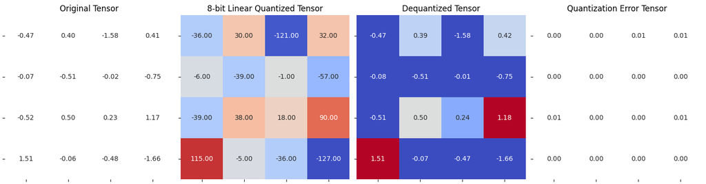

```python
## plot_quantization_errors(test_tensor, quantized_tensor, dequant_tensor)

plot_quantization_errors(test_tensor,
                        quantized_tensor,
                        dequant_tensor,
                        dtype = torch.int8,
                        n_bits = 8)
```

```python
error = quantization_error(test_tensor, dequant_tensor)
error
```

```
tensor(1.5212e-05)
```

## **Asymmetric vs Symmetric Quantization: Key Differences**

### **Asymmetric Quantization**

- **Full utilization of the quantized range**: When using asymmetric quantization, the entire quantized range is utilized, meaning both positive and negative values are mapped effectively, even if the real tensor does not have a symmetric distribution around zero.

### **Symmetric Quantization**

- **Bias handling**: In symmetric quantization, if the floating-point values are biased toward one side (e.g., in ReLU activations), the quantized range will also be biased toward that side. This could lead to suboptimal use of the quantized range if the values are heavily skewed.
- **Simplicity**: Symmetric quantization is generally simpler to implement since it aligns the zero point in both the real tensor and the quantized tensor, resulting in fewer computations.
- **Memory efficiency**: Symmetric quantization is more memory-efficient because there is no need to store the zero point (`z`), which is always set to 0. This saves memory space when dealing with large models.

### **Practical Usage**

- **For 8-bit quantization**: Symmetric quantization is commonly used because it is simple and efficient, and 8-bit precision is often enough for most deep learning models.
- **For lower bit-widths (2-bit, 4-bit)**: Asymmetric quantization is typically preferred when working with lower bit-widths, as it provides more flexibility to handle the reduced precision without losing too much information. The quantized range needs to be adjusted carefully to maintain performance at these lower bit depths.

## **Types of Quantization Methods**

1. **Per Tensor Quantization**  
   In per tensor quantization, the scale and zero-point are applied uniformly across the entire tensor. This approach is simpler but may not always capture fine-grained variations across different parts of the tensor.
2. **Per Channel Quantization**  
   Per channel quantization applies different scales and zero-points to each channel of the tensor (e.g., for each filter in a convolutional layer). This allows for more precision in cases where different channels have different distributions of values, leading to better performance.

### **Summary**

- **Symmetric Quantization**:
  - Simpler and more memory-efficient, as no zero-point storage is required.
  - Suitable for 8-bit quantization.
  - Works well when the data is symmetric or near symmetric.
- **Asymmetric Quantization**:
  - Utilizes the full quantized range.
  - Preferred for lower bit-widths (2 or 4-bit) where precision loss is critical.
  - Suitable when data is not symmetric or biased.

Both quantization methods offer trade-offs, and choosing the right method depends on the bit-width, memory constraints, and model characteristics.

## **Per Channel Quantization**

### Key Points:

[figure not shown]

Dont get intimidated by the function we will break down step by step:

```python
def linear_q_symmetric_per_channel(r_tensor, dim, dtype=torch.int8):

    output_dim = r_tensor.shape[dim]
    # store the scales
    scale = torch.zeros(output_dim)

    for index in range(output_dim):
        sub_tensor = r_tensor.select(dim, index)
        scale[index] = get_q_scale_symmetric(sub_tensor, dtype=dtype)

    # reshape the scale
    scale_shape = [1] * r_tensor.dim()
    scale_shape[dim] = -1
    scale = scale.view(scale_shape)
    quantized_tensor = linear_q_with_scale_and_zero_point(
        r_tensor, scale=scale, zero_point=0, dtype=dtype)

    return quantized_tensor, scale
```

lets make a test tensor and chhose to work with the rows

```python
test_tensor = torch.tensor(
    [[191.5 , -13.5, 728.6],
     [92.14, 295.5, -184],
     [0 , 684.6 , 245.5]
    ]
)

dim = 0

out_dim = test_tensor.shape[dim]
out_dim
```

```
3
```

First we will initilize the scale matriox by zero as the same dims as the output dims

```python
scale = torch.zeros(out_dim)
scale
```

```
tensor([0., 0., 0.])
```

Then we will loop over the channel we choose (rows in our case) , to calculate the scale using the function we alredy make

but make sure to slice the scale with thte right index

```python
for index in range(out_dim):
    sub_tensor = test_tensor.select(dim , index)
    # print(sub_tensor)
    scale[index] = get_q_scale_symmetric(sub_tensor)
    # print(scale[index])

scale
```

```
tensor([5.7370, 2.3268, 5.3906])
```

ndext we need to make the scale matrix in the right shape to make the matrh right (along the rows)

```python
scale_shape = [1] * test_tensor.dim()
scale_shape
```

```
[1, 1]
```

```python
scale_shape[dim] = -1
scale_shape
```

```
[-1, 1]
```

```python
scale = scale.view(scale_shape)
scale
```

```
tensor([[5.7370],
        [2.3268],
        [5.3906]])
```

Now we the right scale for every channel we peform the quantization as normal

notice the diffrent betgween the two output

```python
quantized_tensor = linear_q_with_scale_and_zero_point(test_tensor, scale, zero_point=0)
quantized_tensor
```

```
tensor([[ 33,  -2, 127],
        [ 40, 127, -79],
        [  0, 127,  46]], dtype=torch.int8)
```

```python
### along the rows (dim = 0)
quantized_tensor_0, scale_0 = linear_q_symmetric_per_channel(
    test_tensor, dim=0)

quantized_tensor_0
```

```
tensor([[ 33,  -2, 127],
        [ 40, 127, -79],
        [  0, 127,  46]], dtype=torch.int8)
```

```python
dequantized_tensor_0 = linear_dequantization(
    quantized_tensor_0, scale_0, 0)

dequantized_tensor_0
```

```
tensor([[ 189.3213,  -11.4740,  728.6000],
        [  93.0709,  295.5000, -183.8150],
        [   0.0000,  684.6000,  247.9653]])
```

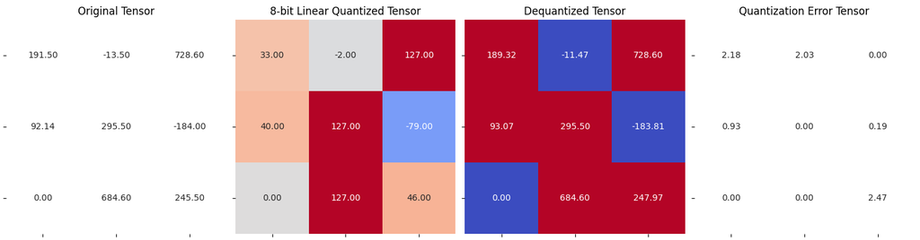

```python
plot_quantization_errors(
    test_tensor, quantized_tensor_0, dequantized_tensor_0)
```

Lets try to switch the dim to 1 and see the result

```python
### along the rows (dim = 1)
quantized_tensor_1, scale_1 = linear_q_symmetric_per_channel(
    test_tensor, dim=1)

quantized_tensor_1
```

```
tensor([[127,  -3, 127],
        [ 61,  55, -32],
        [  0, 127,  43]], dtype=torch.int8)
```

```python
dequantized_tensor_1 = linear_dequantization(
    quantized_tensor_1, scale_1, 1)

dequantized_tensor_1
```

```
tensor([[ 189.9921,  -21.5622,  722.8630],
        [  90.4724,  291.0898, -189.3213],
        [  -1.5079,  679.2094,  240.9543]])
```

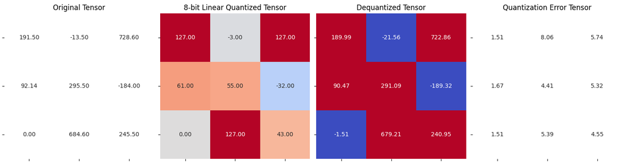

```python
plot_quantization_errors(
    test_tensor, quantized_tensor_1, dequantized_tensor_1)
```

## **Per Group Quantization**

In **per group quantization**, we apply quantization independently to different groups within a tensor. These groups could represent rows, columns, or any arbitrary division along a chosen dimension. Each group will have its own scale and zero-point value, making this approach flexible and more efficient in certain scenarios. This method allows the tensor to have varying precision across different regions or groups.

### Key Points:

[figure not shown]

On the side of practical implenmtaion we can utilize the linear_q_symmetric_per_channel function but we must make sure to the channel by groups number

```python
def linear_q_symmetric_per_group(tensor, group_size,
                                 dtype=torch.int8):

    t_shape = tensor.shape
    assert t_shape[1] % group_size == 0
    assert tensor.dim() == 2

    tensor = tensor.view(-1, group_size)

    quantized_tensor, scale = linear_q_symmetric_per_channel(
                                tensor, dim=0, dtype=dtype)

    quantized_tensor = quantized_tensor.view(t_shape)

    return quantized_tensor, scale
```

```python
def linear_dequantization_per_group(quantized_tensor, scale,
                                    group_size):

    q_shape = quantized_tensor.shape
    quantized_tensor = quantized_tensor.view(-1, group_size)

    dequantized_tensor = linear_dequantization(quantized_tensor,
                                               scale, 0)

    dequantized_tensor = dequantized_tensor.view(q_shape)

    return dequantized_tensor
```

```python
random_tensor =torch.rand((6,6))
group_size = 3
random_tensor
```

```
tensor([[0.7078, 0.2773, 0.1074, 0.7192, 0.9291, 0.3868],
        [0.6233, 0.9084, 0.4258, 0.6934, 0.0043, 0.8045],
        [0.8911, 0.3952, 0.2491, 0.2838, 0.6218, 0.1033],
        [0.1858, 0.4157, 0.9005, 0.4327, 0.9410, 0.8289],
        [0.7739, 0.1458, 0.0269, 0.8652, 0.2573, 0.1619],
        [0.2801, 0.2500, 0.2928, 0.9197, 0.1542, 0.4883]])
```

```python
quantized_tensor , scale = linear_q_symmetric_per_group(random_tensor, group_size)
dequant_tensor  = linear_dequantization_per_group(quantized_tensor, scale, group_size)
```

```python
quantized_tensor
```

```
tensor([[127,  50,  19,  98, 127,  53],
        [ 87, 127,  60, 109,   1, 127],
        [127,  56,  36,  58, 127,  21],
        [ 26,  59, 127,  58, 127, 112],
        [127,  24,   4, 127,  38,  24],
        [121, 108, 127, 127,  21,  67]], dtype=torch.int8)
```

```python
dequant_tensor
```

```
tensor([[0.7078, 0.2787, 0.1059, 0.7170, 0.9291, 0.3878],
        [0.6223, 0.9084, 0.4291, 0.6905, 0.0063, 0.8045],
        [0.8911, 0.3929, 0.2526, 0.2840, 0.6218, 0.1028],
        [0.1843, 0.4183, 0.9005, 0.4297, 0.9410, 0.8298],
        [0.7739, 0.1463, 0.0244, 0.8652, 0.2589, 0.1635],
        [0.2790, 0.2490, 0.2928, 0.9197, 0.1521, 0.4852]])
```

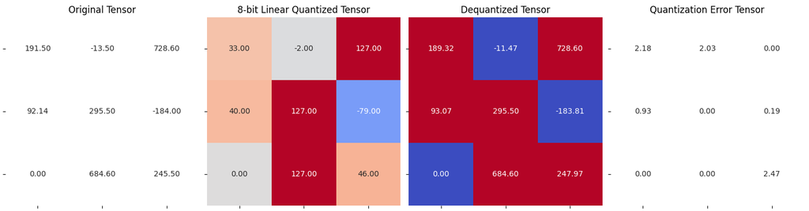

```python
quantized_tensor, scale = linear_q_symmetric_per_group(
    test_tensor, group_size=group_size)

dequantized_tensor = linear_dequantization_per_group(
    quantized_tensor, scale, group_size=group_size)

plot_quantization_errors(
    test_tensor, quantized_tensor, dequantized_tensor)
```

```python
print(f"""Quantization Error : \
{quantization_error(test_tensor, dequantized_tensor)}""")
```

```
Quantization Error : 1.7589133977890015
```

## Now We Have What It Takes to Code Up Our Custom Quantizer

### **Coding a Custom 8-Bit Quantizer:**

In this section, we will design a custom quantizer that is **model agnostic**, meaning it can be applied to any type of model—whether it's for **language models**, **vision models**, or **multimodal models**. The core quantization scheme we’ll use is **linear quantization** to quantize the weights of the model.

### **Steps for the Project:**

1. **Creating a W8A16LinearLayer Class**: This class will be responsible for storing the 8-bit weights and scales.
2. **Replacing the Torch Linear Layer**: We’ll replace the standard PyTorch `Linear` layer with our custom `W8A16LinearLayer` class.
3. **Creating a Function to Quantize the Weights**: This function will handle the quantization of the weights for the entire model.
4. **Testing the Implementation**: Finally, we’ll test our implementation to ensure it works as expected.

### **W8A16LinearLayer Class**:

- **w8_16_forward function**: This function will process weights, input, scale, and bias (optional) during the forward pass.

#### Some Random Tensor for Testing:

Before we dive into the code, let’s first generate some random tensors for testing our quantization function and the W8A16LinearLayer class.

```python
random_int8 = torch.randint(-128, 127, (32, 16), dtype=torch.int8)
random_hs = torch.randn((1, 16), dtype=torch.bfloat16)
scales = torch.randn((1, 32), dtype=torch.bfloat16)
bias = torch.randn((1, 32), dtype=torch.bfloat16)
```

```python
## whats is the diffrent between nn.linear and F.linear ?
## look at this example :
# Using nn.Linear (recommended)

linear_layer = nn.Linear(in_features=10, out_features=5)  # Creates and registers parameters
input_tensor = torch.randn(20, 10) #batch size 20, input features 10
output = linear_layer(input_tensor) #batch size 20, output features 5

print(list(linear_layer.parameters())) #prints the weight and bias of the linear layer

# Using F.linear
w = torch.randn(5, 10)  # You must create the weight tensor
b = torch.randn(5)      # And the bias tensor (optional)
output_f = F.linear(input_tensor, w, b)

print(w) #prints the weight tensor
print(b)   #prints the bias tensor
```

```
[Parameter containing:
tensor([[ 0.2625,  0.1941,  0.2088, -0.0458,  0.1267, -0.2976, -0.0269,  0.2539,
         -0.0661, -0.0040],
        [-0.1867,  0.0027, -0.2036,  0.1895,  0.1635, -0.0823,  0.1375, -0.1075,
          0.1387,  0.2044],
        [-0.0931,  0.1991, -0.0248, -0.2883, -0.0005,  0.1923, -0.1056, -0.0819,
         -0.0357,  0.1282],
        [-0.1814,  0.0488, -0.0526,  0.1770,  0.1688, -0.1380, -0.0084,  0.1199,
          0.0830,  0.1483],
        [ 0.2899, -0.1697,  0.1269, -0.2948,  0.1777, -0.2761, -0.1695,  0.2485,
         -0.0891,  0.0625]], requires_grad=True), Parameter containing:
tensor([-0.2912,  0.2595,  0.3151,  0.0979, -0.2062], requires_grad=True)]
tensor([[-0.5781, -1.2231, -0.3263, -0.4340,  1.6775,  1.4836, -1.6007, -0.1833,
         -0.5445, -0.1194],
        [-0.4951,  1.3371, -1.7376,  0.2296, -0.3397, -1.2458, -0.6335, -1.5690,
         -0.9182, -0.8499],
        [ 0.4297,  0.5863, -0.0082, -2.3707,  2.8987, -1.0881,  0.1197, -1.5391,
         -0.3162, -1.6799],
        [-1.3558,  0.6684,  1.3537,  1.4851,  0.3396,  1.2110,  1.5746,  0.5546,
         -0.7308,  0.2788],
        [-0.0198,  0.8873, -0.0125, -0.1024,  1.7722,  0.7682,  0.7142,  1.5177,
         -1.5608,  3.1433]])
tensor([-0.7333, -0.6826,  0.2566,  1.8127,  0.9559])
```

```python
# Using nn.Linear (recommended) and cASTING the weights to bfloat16 (same as the hiden states)
F.linear(random_hs, random_int8.to(random_hs.dtype))
```

```
tensor([[ 338.0000,  560.0000,  494.0000,  298.0000,  288.0000,   97.0000,
          336.0000,   15.8750,  131.0000, -274.0000,  -85.0000,  -15.6875,
          380.0000,  360.0000, -440.0000,  -89.0000, -243.0000,  228.0000,
          -94.5000,  139.0000,  240.0000,  374.0000, -199.0000,   47.2500,
          -86.0000,  -99.5000, -780.0000,  396.0000, -237.0000,  156.0000,
         -159.0000,   65.5000]], dtype=torch.bfloat16)
```

```python
F.linear(random_hs, random_int8.to(random_hs.dtype)) * scales
```

```
tensor([[ 372.0000,  624.0000,  125.5000,   13.3750, -168.0000,   -3.3594,
           32.2500,  -27.0000,  113.0000,   48.7500,  -78.5000,   -5.5938,
          155.0000,  179.0000,  320.0000,    4.5938, -390.0000,  -74.0000,
            6.7500,   51.2500,  264.0000,  370.0000, -336.0000,  -52.5000,
           40.0000,  213.0000, -792.0000, -246.0000,  296.0000, -163.0000,
          -96.5000,  -23.3750]], dtype=torch.bfloat16)
```

```python
F.linear(random_hs, random_int8.to(random_hs.dtype)) * scales + bias
```

```
tensor([[ 372.0000,  624.0000,  127.5000,   14.4375, -167.0000,   -3.7812,
           32.7500,  -25.6250,  111.5000,   49.5000,  -80.5000,   -6.4375,
          155.0000,  178.0000,  320.0000,    4.3125, -390.0000,  -73.5000,
            8.1875,   50.0000,  264.0000,  368.0000, -336.0000,  -51.5000,
           40.5000,  214.0000, -792.0000, -244.0000,  296.0000, -163.0000,
          -95.5000,  -23.3750]], dtype=torch.bfloat16)
```

## notice that its imporant for the shape of the scale and bias to be the same as the output of the linear layer so you can broadcast the addition correctly

## lets combine this into function:

```python
## lets combine this into function:
def w8_16_forward(weight, input, scale, bias=None):
    casted_weight = weight.to(input.dtype)
    output = F.linear(input, casted_weight) * scale
    if bias is not None:
        output += bias
    return output
```

```python
print("with bias:")
w8_16_forward(random_int8, random_hs, scales, bias)
```

```
with bias:
```

```
tensor([[ 372.0000,  624.0000,  127.5000,   14.4375, -167.0000,   -3.7812,
           32.7500,  -25.6250,  111.5000,   49.5000,  -80.5000,   -6.4375,
          155.0000,  178.0000,  320.0000,    4.3125, -390.0000,  -73.5000,
            8.1875,   50.0000,  264.0000,  368.0000, -336.0000,  -51.5000,
           40.5000,  214.0000, -792.0000, -244.0000,  296.0000, -163.0000,
          -95.5000,  -23.3750]], dtype=torch.bfloat16)
```

```python
print("without bias:")
w8_16_forward(random_int8, random_hs, scales)
```

```
without bias:
```

```
tensor([[ 372.0000,  624.0000,  125.5000,   13.3750, -168.0000,   -3.3594,
           32.2500,  -27.0000,  113.0000,   48.7500,  -78.5000,   -5.5938,
          155.0000,  179.0000,  320.0000,    4.5938, -390.0000,  -74.0000,
            6.7500,   51.2500,  264.0000,  370.0000, -336.0000,  -52.5000,
           40.0000,  213.0000, -792.0000, -246.0000,  296.0000, -163.0000,
          -96.5000,  -23.3750]], dtype=torch.bfloat16)
```

```python
## next lets consider the process

class W8A16LinearLayer(nn.Module):
    def __init__(self, in_features, out_features, bias=True, dtype=torch.float32):
        super().__init__()

        ## this method is wrong but it shows the idea
        self.int8_weight = nn.Parameter(torch.randint(-128, 127, (out_features, in_features)).to(dtype=torch.int8))
```

lets try ti init the class and see what will happen

```python
layer = W8A16LinearLayer(16, 32)
```

```
---------------------------------------------------------------------------
RuntimeError                              Traceback (most recent call last)
Cell In[55], line 1
----> 1 layer = W8A16LinearLayer(16, 32)

Cell In[54], line 8, in W8A16LinearLayer.__init__(self, in_features, out_features, bias, dtype)
      5 super().__init__()
      7 ## this method is wrong but it shows the idea
----> 8 self.int8_weight = nn.Parameter(torch.randint(-128, 127, (out_features, in_features)).to(dtype=torch.int8))

File ~/anaconda3/envs/MyLLM/lib/python3.10/site-packages/torch/nn/parameter.py:46, in Parameter.__new__(cls, data, requires_grad)
     42     data = torch.empty(0)
     43 if type(data) is torch.Tensor or type(data) is Parameter:
     44     # For ease of BC maintenance, keep this path for standard Tensor.
     45     # Eventually (tm), we should change the behavior for standard Tensor to match.
---> 46     return torch.Tensor._make_subclass(cls, data, requires_grad)
     48 # Path for custom tensors: set a flag on the instance to indicate parameter-ness.
     49 t = data.detach().requires_grad_(requires_grad)

RuntimeError: Only Tensors of floating point and complex dtype can require gradients
```

### Addressing the `RuntimeError` in PyTorch

As you may have encountered, when using `nn.Parameter` in PyTorch, it automatically assigns the tensor to the computational graph and expects to track the gradient for backpropagation. However, PyTorch does not currently support gradients for `int8` tensors, which leads to a **`RuntimeError`**.

So, what can we do to address this issue?

look at this:

```python
class W8A16LinearLayer(nn.Module):
    def __init__(self, in_features, out_features, bias=True, dtype=torch.float32):
        super().__init__()

        self.register_buffer("int8_weight",
                            torch.randint(-128, 127, (out_features, in_features)).to(dtype=torch.int8))
```

```python
layer = W8A16LinearLayer(16, 32)
```

register_buffer is a great method to save tensors that should not be considered as model parameters and should not have gradients computed for them. It’s ideal for saving tensors like scale and zero points, which we don’t want to be updated during backpropagation but still need to persist in the model.

Now that we've cleared up the error, let’s continue with implementing the custom 8-bit quantizer. Here's the next step:

```python
class W8A16LinearLayer(nn.Module):
    def __init__(self, in_features, out_features, bias=True, dtype=torch.float32):
        super().__init__()

        self.register_buffer("int8_weight",
                            torch.randint(-128, 127, (out_features, in_features), dtype=torch.int8))

        self.register_buffer("scale", torch.randn((out_features)
                             , dtype=dtype))

        if bias:
            self.register_buffer("bias", torch.zeros((1, out_features)
                                 , dtype=dtype))
        else:
            self.bias = None
```

```python
dummy_instance = W8A16LinearLayer(16, 32)
print(dummy_instance.int8_weight.shape)
print( dummy_instance.scale.shape)
```

```
torch.Size([32, 16])
torch.Size([32])
```

All good now we need the forward pass , which we alredy made:

```python
class W8A16LinearLayer(nn.Module):
    def __init__(self, in_features, out_features, bias=True, dtype=torch.float32):
        super().__init__()

        self.register_buffer("int8_weight",
                            torch.randint(-128, 127, (out_features, in_features), dtype=torch.int8))

        self.register_buffer("scale", torch.randn((out_features)
                             , dtype=dtype))

        if bias:
            self.register_buffer("bias", torch.zeros((1, out_features)
                                 , dtype=dtype))
        else:
            self.bias = None

    def forward(self, x):
        return w8_16_forward(self.int8_weight, x, self.scale, self.bias)
```

```python
dummy_instance = W8A16LinearLayer(16, 32)
dummy_hs = torch.randn(1, 6, 16)

dummy_instance(dummy_hs).dtype
```

```
torch.float32
```

Now lets make quantize and dequantize method , plus the workflow to quantize a model should as follow :

we detect all the linear layer on the model

we loop over thejm and replace the standard nn.linear with the custom made class

```python
class W8A16LinearLayer(nn.Module):
    def __init__(self, in_features, out_features, bias=True, dtype=torch.float32):
        super().__init__()

        self.register_buffer("int8_weight",
                            torch.randint(-128, 127, (out_features, in_features), dtype=torch.int8))

        self.register_buffer("scale", torch.randn((out_features)
                             , dtype=dtype))

        if bias:
            self.register_buffer("bias", torch.zeros((1, out_features)
                                 , dtype=dtype))
        else:
            self.bias = None

    def quantize(self, weight):
        ## cast to fp32 is recommended for stability
        w_fp32 = weight.clone().to(torch.float32)

        scales = w_fp32.abs().max(dim=-1).values / 127
        scales = scales.to(weight.dtype)

        int8_weight = torch.round(w_fp32 / scales.unsqueeze(1)).to(torch.int8)

        self.int8_weight = int8_weight
        self.scale = scales

    def forward(self, input):
        return w8_16_forward(self.int8_weight, input, self.scale, self.bias)
```

```python
dummy_instance = W8A16LinearLayer(4 , 8)

print("before quantization:0", dummy_instance.int8_weight)
```

```
before quantization:0 tensor([[  57,  -85,  -95,   27],
        [  88,  -36,   17,  -95],
        [-106,   49,  -53,   75],
        [  91,  -79,  -32,   37],
        [ -11,   32,  -49, -127],
        [ -37,   68,   74,  -59],
        [  30,   33,  -76,  -22],
        [  49,   10,   48,  -72]], dtype=torch.int8)
```

```python
random_matrix = torch.randn((4, 8), dtype=torch.bfloat16)

dummy_instance.quantize(random_matrix)
print("after quantization:0", dummy_instance.int8_weight)
```

```
after quantization:0 tensor([[ -83,  -53,   85,  127,  -22,  -63,  -16,  -54],
        [ -13, -127,   16,  -77,   50,  -60,   71,  -16],
        [ -10,  -55, -122, -127,  -24,   94,    0,  -44],
        [  43,  123,  119,   34, -127,   14,  -57,  -74]], dtype=torch.int8)
```

```python
dummy_instance.scale.shape
```

```
torch.Size([4])
```

```python
dummy_instance.int8_weight.shape
```

```
torch.Size([4, 8])
```

Lets calculate the quantization_error

```python
quantization_error = (random_matrix - dummy_instance.int8_weight * dummy_instance.scale.unsqueeze(1)).abs().mean()
quantization_error
```

```
tensor(0.0025, dtype=torch.bfloat16)
```

Now we ready to make Quantizer (a quantization pipline) which will iterate over the original linear model and replace them with the int8

```python
def replace_module(module,
                target_class,
                module_name_to_exclude):

    for name, child in module.named_children():

        # if the layer is a linear layer and not in the exclusion list
        if isinstance(child, nn.Linear) and not any([x == name for x in module_name_to_exclude]):
            old_bias = child.bias
            new_module = target_class(
                child.in_features,
                child.out_features,
                child.bias is not None,
                child.weight.dtype
            )
            setattr(module, name, new_module)
            if old_bias is not None:
                getattr(module , name).bias = old_bias

        else :
            # recursively call the function
            replace_module(child, target_class, module_name_to_exclude)
```

```python
# LETS MAKE A DUMMY MODEL (LIKE MINI GPT)
class DummyModel(nn.Module):
    def __init__(self):
        super().__init__()
        self.l1 = nn.Embedding(16, 32)
        # with bias
        self.l2 = nn.Linear(32, 64)
        # without bias
        self.l3 = nn.Linear(64, 128, bias=False)
        self.l4 = nn.Linear(128, 256, bias=False)
```

```python
model_1 = DummyModel()
model_2 = DummyModel()

replace_module(model_1, W8A16LinearLayer, ["l4"])

print("quantized model:",model_1)

print ("unquantized model:",model_2)
```

```
quantized model: DummyModel(
  (l1): Embedding(16, 32)
  (l2): W8A16LinearLayer()
  (l3): W8A16LinearLayer()
  (l4): Linear(in_features=128, out_features=256, bias=False)
)
unquantized model: DummyModel(
  (l1): Embedding(16, 32)
  (l2): Linear(in_features=32, out_features=64, bias=True)
  (l3): Linear(in_features=64, out_features=128, bias=False)
  (l4): Linear(in_features=128, out_features=256, bias=False)
)
```

```python
def replace_module_and_quantize(module,
                target_class,
                module_name_to_exclude):

    for name, child in module.named_children():

        # if the layer is a linear layer and not in the exclusion list
        if isinstance(child, nn.Linear) and not any([x == name for x in module_name_to_exclude]):
            old_bias = child.bias
            old_weight = child.weight

            new_module = target_class(
                child.in_features,
                child.out_features,
                child.bias is not None,
                child.weight.dtype
            )
            setattr(module, name, new_module)
            getattr(module , name).quantize(old_weight)

            if old_bias is not None:
                getattr(module , name).bias = old_bias

        else :
            # recursively call the function
            replace_module_and_quantize(child, target_class, module_name_to_exclude)
```

```python
model_3 = DummyModel()

replace_module_and_quantize(model_3, W8A16LinearLayer, ["l4"])

print("quantized model:",model_3)
```

```
quantized model: DummyModel(
  (l1): Embedding(16, 32)
  (l2): W8A16LinearLayer()
  (l3): W8A16LinearLayer()
  (l4): Linear(in_features=128, out_features=256, bias=False)
)
```

Lets test the implentaion on a real model

```python
from UTILS.load_weights import download_and_load_gpt2 , load_weights_into_gpt
from UTILS.model import GPTModel

## Choose the model to use
CHOOSE_MODEL = "gpt2-medium (355M)"

## Base configuration settings for the model
BASE_CONFIG = {
    "vocab_size": 50257,     # Size of the vocabulary used by the model
    "context_length": 1024,  # Maximum context length the model can handle
    "drop_rate": 0.0,        # Dropout rate for regularization
    "qkv_bias": True         # Whether to use bias terms in query, key, and value projections
}

## Dictionary containing configurations for different GPT-2 model sizes
model_configs = {
    "gpt2-small (124M)": {"emb_dim": 768, "n_layers": 12, "n_heads": 12},      # Config for small model
    "gpt2-medium (355M)": {"emb_dim": 1024, "n_layers": 24, "n_heads": 16},    # Config for medium model
    "gpt2-large (774M)": {"emb_dim": 1280, "n_layers": 36, "n_heads": 20},     # Config for large model
    "gpt2-xl (1558M)": {"emb_dim": 1600, "n_layers": 48, "n_heads": 25},       # Config for extra-large model
}

## Update the BASE_CONFIG with parameters specific to the chosen model
BASE_CONFIG.update(model_configs[CHOOSE_MODEL])

model_size = CHOOSE_MODEL.split(" ")[-1].lstrip("(").rstrip(")")
settings, params = download_and_load_gpt2(model_size=model_size, models_dir="gpt2")

model = GPTModel(BASE_CONFIG)
load_weights_into_gpt(model, params)
model.eval()
```

```
File already exists and is up-to-date: gpt2/355M/checkpoint
File already exists and is up-to-date: gpt2/355M/encoder.json
File already exists and is up-to-date: gpt2/355M/hparams.json
File already exists and is up-to-date: gpt2/355M/model.ckpt.data-00000-of-00001
File already exists and is up-to-date: gpt2/355M/model.ckpt.index
File already exists and is up-to-date: gpt2/355M/model.ckpt.meta
File already exists and is up-to-date: gpt2/355M/vocab.bpe
```

```
GPTModel(
  (tok_emb): Embedding(50257, 1024)
  (pos_emb): Embedding(1024, 1024)
  (drop_emb): Dropout(p=0.0, inplace=False)
  (trf_blocks): Sequential(
    (0): TransformerBlock(
      (att): MultiHeadAttention(
        (W_query): Linear(in_features=1024, out_features=1024, bias=True)
        (W_key): Linear(in_features=1024, out_features=1024, bias=True)
        (W_value): Linear(in_features=1024, out_features=1024, bias=True)
        (out_proj): Linear(in_features=1024, out_features=1024, bias=True)
        (dropout): Dropout(p=0.0, inplace=False)
      )
      (ff): FeedForward(
        (layers): Sequential(
          (0): Linear(in_features=1024, out_features=4096, bias=True)
          (1): GELU()
          (2): Linear(in_features=4096, out_features=1024, bias=True)
        )
      )
      (norm1): LayerNorm()
      (norm2): LayerNorm()
      (drop_resid): Dropout(p=0.0, inplace=False)
    )
    (1): TransformerBlock(
      (att): MultiHeadAttention(
        (W_query): Linear(in_features=1024, out_features=1024, bias=True)
        (W_key): Linear(in_features=1024, out_features=1024, bias=True)
        (W_value): Linear(in_features=1024, out_features=1024, bias=True)
        (out_proj): Linear(in_features=1024, out_features=1024, bias=True)
        (dropout): Dropout(p=0.0, inplace=False)
      )
      (ff): FeedForward(
        (layers): Sequential(
          (0): Linear(in_features=1024, out_features=4096, bias=True)
          (1): GELU()
          (2): Linear(in_features=4096, out_features=1024, bias=True)
        )
      )
      (norm1): LayerNorm()
```

[output cut: 410 more lines]

```
      (ff): FeedForward(
        (layers): Sequential(
          (0): Linear(in_features=1024, out_features=4096, bias=True)
          (1): GELU()
          (2): Linear(in_features=4096, out_features=1024, bias=True)
        )
      )
      (norm1): LayerNorm()
      (norm2): LayerNorm()
      (drop_resid): Dropout(p=0.0, inplace=False)
    )
  )
  (final_norm): LayerNorm()
  (out_head): Linear(in_features=1024, out_features=50257, bias=False)
)
```

## **Model Size Comparison Before and After Quantization**

In this section, we'll compare the model size before and after applying quantization. Additionally, we will test the model's generation capability to check if there is any significant impact on performance.

### Key Points:

- **Model Size**: Quantization is expected to reduce the model size by representing weights with lower precision (e.g., from float32 to int8).
- **Generation Capability**: We will evaluate the model's ability to generate outputs both before and after quantization to assess whether the quantization process introduces any noticeable degradation in its performance.

### Steps:

1. **Before Quantization**: We'll first check the model size before applying quantization.
2. **After Quantization**: Then, we'll apply quantization to the model weights and check the model size again.
3. **Testing Model Generation**: We will test the model's generation capability before and after quantization to verify if the quantization has affected the model's performance.

```python
def model_info(model):
    """
    Returns the number of parameters and size in MB of a PyTorch model.

    Args:
        model (torch.nn.Module): The PyTorch model.

    Returns:
        tuple: (num_params, size_in_MB)
    """
    num_params = sum(p.numel() for p in model.parameters())
    size_in_MB = sum(p.element_size() * p.numel() for p in model.parameters()) / (1024 * 1024)

    return num_params, size_in_MB


num_params, size_in_MB = model_info(model)
print(f"Number of parameters: {num_params}")
print(f"Size of model in MB: {size_in_MB}")
print(f"Model size: {model_size}")
print(f"size in BG: {size_in_MB/1024}")
```

```
Number of parameters: 406286336
Size of model in MB: 1549.859375
Model size: 355M
size in BG: 1.5135345458984375
```

We load the gpt(335M) we built before and we can see it take a round 1.5 GB

Noe lets generate some text before the quantization operation

```python
import time
import torch
import tiktoken
from UTILS.generate import generate

# Detect device
device = "cuda" if torch.cuda.is_available() else "mps" if torch.backends.mps.is_available() else "cpu"
print(f"Using device: {device}")

# Move model to detected device
gpt = model.to(device)

# Initialize tokenizer
tokenizer = tiktoken.get_encoding('gpt2')

# Tokenize input and move to device
prompt = "I have a dream that "
input_ids = torch.tensor(tokenizer.encode(prompt), dtype=torch.long).unsqueeze(0).to(device)

# Measure time
start_time = time.time()

# Run text generation
generated_text = generate(
    model=gpt,
    prompt=prompt,
    max_new_tokens=100,  # Increased for longer, coherent output
    context_size=512,
    tokenizer=tokenizer,
    temperature=0.5,  # Lower for more coherence
    top_k=50,  # Limits choices to top 50 most probable tokens
    top_p=None,  # Use only one of top_k or top_p
)

# Measure end time
end_time = time.time()

# Print generated text
print(generated_text)

# Print benchmark results
print(f"Inference Time: {end_time - start_time:.4f} seconds")
```

```
Using device: cuda
I have a dream that ____ will stop being a horrible person and start loving me back. It's not easy, but I promise it's worth it."

The story was shared on Facebook, and it was shared so many times that it got the attention of the president.

"I want to thank you so much for your kind words," Trump wrote. "I am a proud and proud American. I love you all."

Trump also wrote, "I want to thank my wife Melania and my family
Inference Time: 4.3826 seconds
```

## Lets Quantize !

```python
replace_module_and_quantize(model, W8A16LinearLayer, ["out_head"])

print("quantized model:",model)
```

```
quantized model: GPTModel(
  (tok_emb): Embedding(50257, 1024)
  (pos_emb): Embedding(1024, 1024)
  (drop_emb): Dropout(p=0.0, inplace=False)
  (trf_blocks): Sequential(
    (0): TransformerBlock(
      (att): MultiHeadAttention(
        (W_query): W8A16LinearLayer()
        (W_key): W8A16LinearLayer()
        (W_value): W8A16LinearLayer()
        (out_proj): W8A16LinearLayer()
        (dropout): Dropout(p=0.0, inplace=False)
      )
      (ff): FeedForward(
        (layers): Sequential(
          (0): W8A16LinearLayer()
          (1): GELU()
          (2): W8A16LinearLayer()
        )
      )
      (norm1): LayerNorm()
      (norm2): LayerNorm()
      (drop_resid): Dropout(p=0.0, inplace=False)
    )
    (1): TransformerBlock(
      (att): MultiHeadAttention(
        (W_query): W8A16LinearLayer()
        (W_key): W8A16LinearLayer()
        (W_value): W8A16LinearLayer()
        (out_proj): W8A16LinearLayer()
        (dropout): Dropout(p=0.0, inplace=False)
      )
      (ff): FeedForward(
        (layers): Sequential(
          (0): W8A16LinearLayer()
          (1): GELU()
          (2): W8A16LinearLayer()
        )
      )
      (norm1): LayerNorm()
```

[output cut: 410 more lines]

```
      (ff): FeedForward(
        (layers): Sequential(
          (0): W8A16LinearLayer()
          (1): GELU()
          (2): W8A16LinearLayer()
        )
      )
      (norm1): LayerNorm()
      (norm2): LayerNorm()
      (drop_resid): Dropout(p=0.0, inplace=False)
    )
  )
  (final_norm): LayerNorm()
  (out_head): Linear(in_features=1024, out_features=50257, bias=False)
)
```

```python
import time
import torch
import tiktoken
from UTILS.generate import generate

# Detect device
device = "cuda" if torch.cuda.is_available() else "mps" if torch.backends.mps.is_available() else "cpu"
print(f"Using device: {device}")

# Move model to detected device
gpt = model.to(device)

# Initialize tokenizer
tokenizer = tiktoken.get_encoding('gpt2')

# Tokenize input and move to device
prompt = "I have a dream that "
input_ids = torch.tensor(tokenizer.encode(prompt), dtype=torch.long).unsqueeze(0).to(device)

# Measure time
start_time = time.time()

# Run text generation
generated_text = generate(
    model=gpt,
    prompt=prompt,
    max_new_tokens=100,  # Increased for longer, coherent output
    context_size=512,
    tokenizer=tokenizer,
    temperature=0.5,  # Lower for more coherence
    top_k=50,  # Limits choices to top 50 most probable tokens
    top_p=None,  # Use only one of top_k or top_p
)

# Measure end time
end_time = time.time()

# Print generated text
print(generated_text)

# Print benchmark results
print(f"Inference Time: {end_time - start_time:.4f} seconds")
```

```
Using device: cuda
I have a dream that _____ will stop by my house and say, 'Hi, how's it going?' "

The next morning, the boy's mother called her son's father, who told her that his son had died of a heart attack.

"He said, 'My son is dead. I'm so sorry,'" the mother says. "I was so distraught."

The mother called police to report the death, but police didn't believe her.

The next morning, the boy
Inference Time: 5.3446 seconds
```

As you see there are no noticable effev=ct in the model peformance

lets check and see the model size after the quantization operation

```python
num_params, size_in_MB = model_info(model)
print(f"Number of parameters: {num_params}")
print(f"Size of model in MB: {size_in_MB}")
```

```
Number of parameters: 104296448
Size of model in MB: 397.859375
```

## **Impressive Model Size Reduction**

### How Amazing is This?

This is a huge win in terms of **model optimization**. With quantization, you've just learned how to shrink your model size significantly, allowing you to handle that annoying **CUDA memory error** that often arises with large models.

### Why is This Important?

Reducing the size of the model means:

- **Lower memory usage** during inference.
- **Faster deployment** due to reduced storage requirements.
- The ability to run on **smaller hardware** without running into memory issues.

### What's Next?

While quantization is a powerful technique, there are still **tons of optimizations** you can apply to make your model even more efficient. But now, you have learned the foundation of one of the most crucial optimization techniques in model deployment!

## **Now You Can Quantize Any Open-Source Model!**

As we mentioned earlier, this quantizer is **model-agnostic**, so it can work with a huge variety of models. To test that, let’s load an **object detection model from Facebook** using Hugging Face and apply the quantization on it.

```python
from transformers import DetrImageProcessor, DetrForObjectDetection
from PIL import Image
import requests

# you can specify the revision tag if you don't want the timm dependency
processor = DetrImageProcessor.from_pretrained(
    "facebook/detr-resnet-50", revision="no_timm")
model = DetrForObjectDetection.from_pretrained(
    "facebook/detr-resnet-50", revision="no_timm")


model
```

```
DetrForObjectDetection(
  (model): DetrModel(
    (backbone): DetrConvModel(
      (conv_encoder): DetrConvEncoder(
        (model): ResNetBackbone(
          (embedder): ResNetEmbeddings(
            (embedder): ResNetConvLayer(
              (convolution): Conv2d(3, 64, kernel_size=(7, 7), stride=(2, 2), padding=(3, 3), bias=False)
              (normalization): DetrFrozenBatchNorm2d()
              (activation): ReLU()
            )
            (pooler): MaxPool2d(kernel_size=3, stride=2, padding=1, dilation=1, ceil_mode=False)
          )
          (encoder): ResNetEncoder(
            (stages): ModuleList(
              (0): ResNetStage(
                (layers): Sequential(
                  (0): ResNetBottleNeckLayer(
                    (shortcut): ResNetShortCut(
                      (convolution): Conv2d(64, 256, kernel_size=(1, 1), stride=(1, 1), bias=False)
                      (normalization): DetrFrozenBatchNorm2d()
                    )
                    (layer): Sequential(
                      (0): ResNetConvLayer(
                        (convolution): Conv2d(64, 64, kernel_size=(1, 1), stride=(1, 1), bias=False)
                        (normalization): DetrFrozenBatchNorm2d()
                        (activation): ReLU()
                      )
                      (1): ResNetConvLayer(
                        (convolution): Conv2d(64, 64, kernel_size=(3, 3), stride=(1, 1), padding=(1, 1), bias=False)
                        (normalization): DetrFrozenBatchNorm2d()
                        (activation): ReLU()
                      )
                      (2): ResNetConvLayer(
                        (convolution): Conv2d(64, 256, kernel_size=(1, 1), stride=(1, 1), bias=False)
                        (normalization): DetrFrozenBatchNorm2d()
                        (activation): Identity()
                      )
                    )
                    (activation): ReLU()
```

[output cut: 383 more lines]

```
          (fc2): Linear(in_features=2048, out_features=256, bias=True)
          (final_layer_norm): LayerNorm((256,), eps=1e-05, elementwise_affine=True)
        )
      )
      (layernorm): LayerNorm((256,), eps=1e-05, elementwise_affine=True)
    )
  )
  (class_labels_classifier): Linear(in_features=256, out_features=92, bias=True)
  (bbox_predictor): DetrMLPPredictionHead(
    (layers): ModuleList(
      (0-1): 2 x Linear(in_features=256, out_features=256, bias=True)
      (2): Linear(in_features=256, out_features=4, bias=True)
    )
  )
)
```

Lets check the momery usage using hugging face function

```python
previous_memory_footprint = model.get_memory_footprint()

print(f"Previous memory footprint: {previous_memory_footprint} bytes")
```

```
Previous memory footprint: 166524032 bytes
```

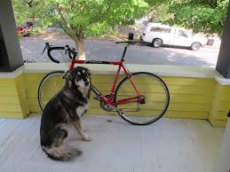

```python
img_path = "images/dog.jpeg"
image = Image.open(img_path).convert("RGB")
image
```

```python
# colors for visualization
COLORS = [[0.000, 0.447, 0.741], [0.850, 0.325, 0.098], [0.929, 0.694, 0.125],
          [0.494, 0.184, 0.556], [0.466, 0.674, 0.188], [0.301, 0.745, 0.933]]

def plot_results(model, pil_img, results):
    plt.figure(figsize=(16,10))
    plt.imshow(pil_img)
    ax = plt.gca()
    scores, labels, boxes = results["scores"], results["labels"], results["boxes"]
    colors = COLORS * 100
    for score, label, (xmin, ymin, xmax, ymax),c  in zip(scores.tolist(), labels.tolist(), boxes.tolist(), colors):
        ax.add_patch(plt.Rectangle((xmin, ymin), xmax - xmin, ymax - ymin,
                                   fill=False, color=c, linewidth=3))
        text = f'{model.config.id2label[label]}: {score:0.2f}'
        ax.text(xmin, ymin, text, fontsize=15,
                bbox=dict(facecolor='yellow', alpha=0.5))
    plt.axis('off')
    plt.show()
```

```python
inputs = processor(images=image, return_tensors="pt")
with torch.no_grad():
  outputs = model(**inputs)

# convert outputs (bounding boxes and class logits) to COCO API
# let's only keep detections with score > 0.9
target_sizes = torch.tensor([image.size[::-1]])
results = processor.post_process_object_detection(outputs, target_sizes=target_sizes, threshold=0.9)[0]
```

```python
results
```

```
{'scores': tensor([0.9996, 0.9992, 0.9911]),
 'labels': tensor([18,  2,  3]),
 'boxes': tensor([[ 44.2972,  74.7842, 105.1044, 181.1416],
         [ 42.6050,  39.3565, 191.2130, 141.2440],
         [160.1061,  26.4939, 229.5246,  56.2601]])}
```

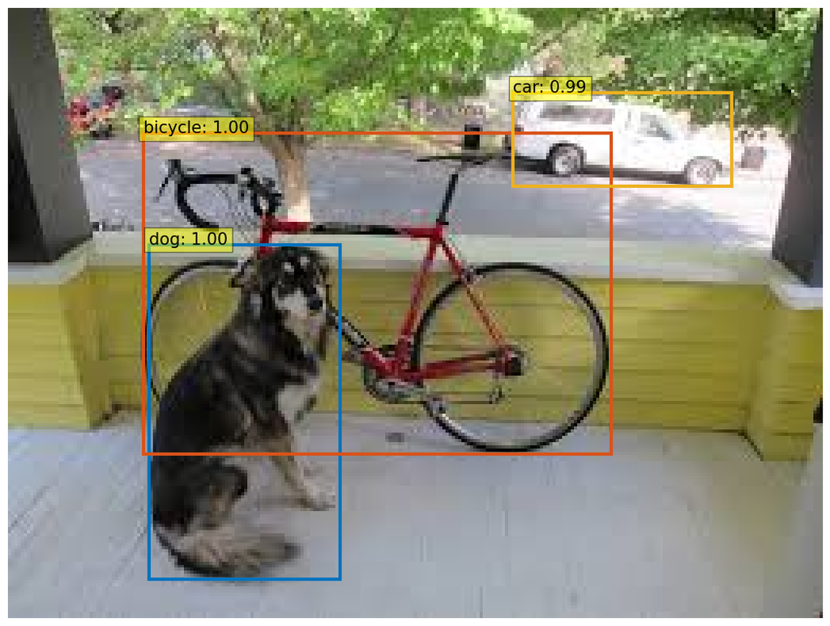

```python
plot_results(model, image, results)
```

## Lets Quantize !

```python
replace_module_and_quantize(model,
                                        W8A16LinearLayer,
               ["0", "1", "2", "class_labels_classifier"])
```

```python
model
```

```
DetrForObjectDetection(
  (model): DetrModel(
    (backbone): DetrConvModel(
      (conv_encoder): DetrConvEncoder(
        (model): ResNetBackbone(
          (embedder): ResNetEmbeddings(
            (embedder): ResNetConvLayer(
              (convolution): Conv2d(3, 64, kernel_size=(7, 7), stride=(2, 2), padding=(3, 3), bias=False)
              (normalization): DetrFrozenBatchNorm2d()
              (activation): ReLU()
            )
            (pooler): MaxPool2d(kernel_size=3, stride=2, padding=1, dilation=1, ceil_mode=False)
          )
          (encoder): ResNetEncoder(
            (stages): ModuleList(
              (0): ResNetStage(
                (layers): Sequential(
                  (0): ResNetBottleNeckLayer(
                    (shortcut): ResNetShortCut(
                      (convolution): Conv2d(64, 256, kernel_size=(1, 1), stride=(1, 1), bias=False)
                      (normalization): DetrFrozenBatchNorm2d()
                    )
                    (layer): Sequential(
                      (0): ResNetConvLayer(
                        (convolution): Conv2d(64, 64, kernel_size=(1, 1), stride=(1, 1), bias=False)
                        (normalization): DetrFrozenBatchNorm2d()
                        (activation): ReLU()
                      )
                      (1): ResNetConvLayer(
                        (convolution): Conv2d(64, 64, kernel_size=(3, 3), stride=(1, 1), padding=(1, 1), bias=False)
                        (normalization): DetrFrozenBatchNorm2d()
                        (activation): ReLU()
                      )
                      (2): ResNetConvLayer(
                        (convolution): Conv2d(64, 256, kernel_size=(1, 1), stride=(1, 1), bias=False)
                        (normalization): DetrFrozenBatchNorm2d()
                        (activation): Identity()
                      )
                    )
                    (activation): ReLU()
```

[output cut: 383 more lines]

```
          (fc2): W8A16LinearLayer()
          (final_layer_norm): LayerNorm((256,), eps=1e-05, elementwise_affine=True)
        )
      )
      (layernorm): LayerNorm((256,), eps=1e-05, elementwise_affine=True)
    )
  )
  (class_labels_classifier): Linear(in_features=256, out_features=92, bias=True)
  (bbox_predictor): DetrMLPPredictionHead(
    (layers): ModuleList(
      (0-1): 2 x Linear(in_features=256, out_features=256, bias=True)
      (2): Linear(in_features=256, out_features=4, bias=True)
    )
  )
)
```

checking the new momery usage

```python
new_footprint = model.get_memory_footprint()

print(f"Previous memory footprint: {new_footprint} bytes")
```

```
Previous memory footprint: 114803840 bytes
```

```python
inputs = processor(images=image, return_tensors="pt")
with torch.no_grad():
  outputs = model(**inputs)

# convert outputs (bounding boxes and class logits) to COCO API
# let's only keep detections with score > 0.9
target_sizes = torch.tensor([image.size[::-1]])
results = processor.post_process_object_detection(outputs, target_sizes=target_sizes, threshold=0.9)[0]
```

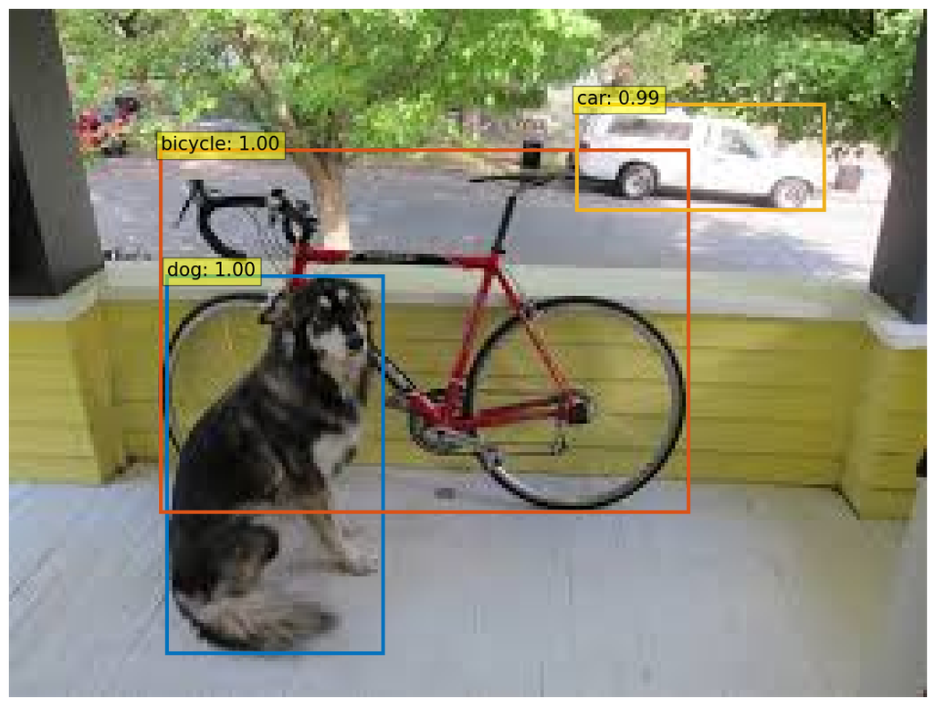

```python
plot_results(model, image, results)
```

We save nearly third of the moodel memory

```python
### Memory saved
print("Memory saved in MBs: ",
      (previous_memory_footprint - new_footprint)/1e+6)
```

```
Memory saved in MBs:  51.720192
```

## **Congratulations! 🎉**

You've just completed an essential exploration into **model quantization**—a foundational optimization technique that can significantly reduce model size and memory usage while maintaining performance. You learned how to implement a custom **8-bit quantizer** and tested it on various models to shrink their size. This is an invaluable skill, especially when dealing with hardware constraints like limited GPU memory. 🚀

## **What's Next? 🚀**

Having mastered linear quantization, it's time to take things further. The next step is exploring **State-of-the-Art (SOTA) methods** for scaling large models. These methods are designed to handle **outliers** and model weights that may not fit well within the constraints of simple linear quantization. For example:

- **Non-linear quantization** techniques, like **logarithmic quantization** and **adaptive quantization**, can better handle extreme outliers in the weight distribution.
- **Mixed-Precision Quantization**: In some layers, you may want to use higher bit precision (like 16-bit) to avoid significant performance degradation in critical sections of the model.
- **Dynamic Quantization** and **Quantization-Aware Training (QAT)**: These methods improve upon static quantization by incorporating quantization during the training process, ensuring that the model adapts to the reduced precision, leading to better accuracy retention.

## **Why Linear Quantization Fails for Certain Models**

Linear quantization works well for models with relatively uniform weight distributions, but in practice, many models, especially large ones, have **outliers**—weights that are significantly larger or smaller than the rest. Linear quantization does not handle these extreme values well, as it scales all the weights by the same factor. This can result in the loss of important information or precision.

In the next steps, we'll explore advanced quantization strategies that address this issue and ensure that the model maintains accuracy while being optimized for hardware efficiency.

Stay tuned! 🎯